# Miniproyecto 2

## Modelación y Simulación

Javier Anleu Alegría - 17149

Andrea Argüello Barillas - 17801

```python
import random
from matplotlib import pyplot as plt
import numpy as np
```

La **Ley de los Grandes Números** establece que el promedio de los resultados de un experimento tenderá al valor esperado mientras más veces se repita el experimento. Existen dos formas de describirla: la Ley Débil o la Ley Fuerte.

*Ley Débil de los Grandes Números*

La ley débil establece que la media de una muestra de valores de una misma distribución converge en probabilidad con el valor esperado, tal que:

$$ \overline X_n \xrightarrow {\text{P}} \mu \quad \text{cuando} \quad n \to \infty $$

En términos de probabilidad, se puede expresar por medio de la desigualdad de Chebyshev:

$$ \lim_{n\to\infty} P\Big(|\overline X_n - \mu|> \varepsilon \Big) = 0 $$

*Ley Fuerte de los Grandes Números*

La ley fuerte se plantea de manera similar. Establece que la media de una muestra de valores de una distribución converge casi seguramente tal que:

$$ \overline X_n \xrightarrow {\text{casi seguramente}} \mu \quad \text{cuando} \quad n \to \infty $$

En términos de probabilidad, se puede expresar de la siguiente manera:

$$ P \Big(\lim_{n\to\infty} \overline X_n = \mu \Big) = 1 $$

### Generación de números aleatorios y cálculo de medias parciales

Recordar que, para una distribución continua uniforme, $$ \mu = \frac{a+b}{2} $$

Si $a = 0$ y $b = 1$, entonces $$ \mu = \frac{0+1}{2}=\frac{1}{2}$$

### Definición de función para calcular la media de la lista

```python
array_avg = lambda X: sum(X)/len(X)
```

### Prueba inicial

```python
# Configuración de la seed para el random
random.seed(123)

# Lista para almacenar los números x_i
x = []

# Lista para almacenar los valores de la media conforme se generan los números
s_n = []

# Lista para almacenar los valores teóricos de la media
mu = []

for i in range(0,1000):
    x.append(random.random())
    s_n.append(array_avg(x))
    mu.append(0.5)
```

### Gráfica de $n$ vs $s_n$

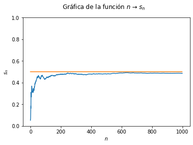

```python
plt.plot(np.arange(0,len(s_n)), s_n, mu)

plt.xlabel('$n$')
plt.ylabel('$s_n$')
plt.suptitle('Gráfica de la función $n$ → $s_n$')
plt.ylim(0, 1)
plt.show()
```

Si bien el valor esperado experimental tiende hacia la media teórica, se esperaría un comportamiento oscilatorio respecto a la media. Sin embargo, se asemeja más al comportamiento de una función racional, de la forma $f(x) = -\frac{a}{x}$ donde $a>0$, ya que nunca cruza la asíntota. Esto podría deberse al algoritmo para generar los números aleatorios, ya que únicamente asimila un comportamiento aleatorio.

### Prueba fijando el primer valor

Se intentó fijar el primer valor a 0.75 para observar el comportamiento y determinar si el comportamiento racional se debía al algoritmo de números pseudoaleatorios.

```python
# Configuración de la seed para el random
random.seed(123)

# Lista para almacenar los números x_i
x = []

# Lista para almacenar los valores de la media conforme se generan los números
s_n = []

# Lista para almacenar los valores teóricos de la media
mu = []

for i in range(0,1000):
    if i == 0:
        x.append(0.75)
        s_n.append(array_avg(x))
        mu.append(0.5)
    else:
        x.append(random.random())
        s_n.append(array_avg(x))
        mu.append(0.5)
```

### Gráfica de $n$ vs $s_n$

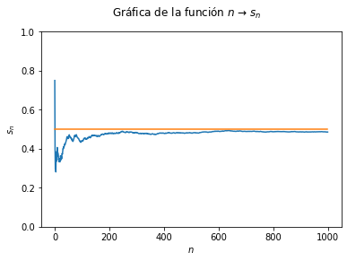

```python
plt.plot(np.arange(0,len(s_n)), s_n, mu)

plt.xlabel('$n$')
plt.ylabel('$s_n$')
plt.suptitle('Gráfica de la función $n$ → $s_n$')
plt.ylim(0, 1)
plt.show()
```

Aunque la gráfica cambió ligeramente en los valores iniciales, nuevamente el la media experimental no cruza el valor esperado teórico. Esto indica que que efectivamente el comportamiento se debe al algoritmo de números aleatorios. Para corregirlo, se pueden hacer pruebas con otras *seeds* hasta encontrar una apropiada.

### Pruebas con distintas *seeds*

#### *Seed:* 237

```python
# Configuración de la seed para el random
random.seed(237)

# Lista para almacenar los números x_i
x = []

# Lista para almacenar los valores de la media conforme se generan los números
s_n = []

# Lista para almacenar los valores teóricos de la media
mu = []

for i in range(0,1000):
    x.append(random.random())
    s_n.append(array_avg(x))
    mu.append(0.5)
```

### Gráfica de $n$ vs $s_n$

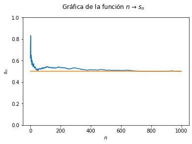

```python
plt.plot(np.arange(0,len(s_n)), s_n, mu)

plt.xlabel('$n$')
plt.ylabel('$s_n$')
plt.suptitle('Gráfica de la función $n$ → $s_n$')
plt.ylim(0, 1)
plt.show()
```

#### *Seed:* 257

```python
# Configuración de la seed para el random
random.seed(257)

# Lista para almacenar los números x_i
x = []

# Lista para almacenar los valores de la media conforme se generan los números
s_n = []

# Lista para almacenar los valores teóricos de la media
mu = []

for i in range(0,1000):
    x.append(random.random())
    s_n.append(array_avg(x))
    mu.append(0.5)
```

### Gráfica de $n$ vs $s_n$

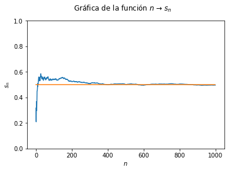

```python
plt.plot(np.arange(0,len(s_n)), s_n, mu)

plt.xlabel('$n$')
plt.ylabel('$s_n$')
plt.suptitle('Gráfica de la función $n$ → $s_n$')
plt.ylim(0, 1)
plt.show()
```

#### *Seed:* 2573

```python
# Configuración de la seed para el random
random.seed(2573)

# Lista para almacenar los números x_i
x = []

# Lista para almacenar los valores de la media conforme se generan los números
s_n = []

# Lista para almacenar los valores teóricos de la media
mu = []

for i in range(0,1000):
    x.append(random.random())
    s_n.append(array_avg(x))
    mu.append(0.5)
```

### Gráfica de $n$ vs $s_n$

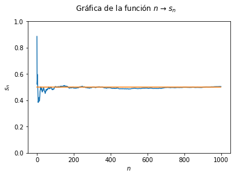

```python
plt.plot(np.arange(0,len(s_n)), s_n, mu)

plt.xlabel('$n$')
plt.ylabel('$s_n$')
plt.suptitle('Gráfica de la función $n$ → $s_n$')
plt.ylim(0, 1)
plt.show()
```

Con el *seed* 2573 se observa el comportamiento oscilatorio esperado del valor esperado experimental alrededor de la media teórica, por lo que esta *seed* es una de las opciones ideales para la simulación.

### Conclusión

Se comprobó que $ s_n \xrightarrow[n \to \infty]{} \mu$ por medio de la simulación de números aleatorios de una distribución uniforme $\mathscr{U}(0,1)$ utilizando $n=1000$.

Se determinó que el *seed* del algoritmo pseudoaleatorio es un parámetro que puede influenciar el desempeño de la simulación y su representación del fenómeno.